# Palomino_Riquero_Christian_Actividad2

# Tarea 1

## Parte 1

Representar en un gráfico para cada valor de probabilidad p=0,5, 0,1 y 0,05, la evolución de la aproximación de las distribuciones binomiales con n=3,10,25,50 a su correspondiente distribución normal (Nota: se debe hacer un gráfico para 0,5 con todas las n, otro para 0,1 con todas las n y otro para 0,05 con todas las n).

### Resolución

Debido a que debemos iterar para cada valor de probabilidad con su respectivo valor de n, crearemos una función que reciba como parámetro la probabilidad que se vaya a iterar sobre todos los valores de n desfinidos en el enunciado.Y realizaremos la sistematización del siguiente algoritmo:

1. Creamos la función que recibe como parámetro la probabilidad p.
2. establecemos los valores de estilo de nuestro gráfico, en este caso, los colores y el tipo de línea.
3. Definimos los valores de n que se van a iterar (3, 10, 25, 50) en un vector.
4. Creamos un marco vacío para el gráfico.
5. Iteramos sobre los distintos valores de n.
   - Establecemos el rango de valores de x según el vector creado en el paso 3.
   - Calculamos la distribución binomial.
   - Calculamos la distribución normal aproximada.
   - Agregamos las líneas al gráfico, utilizamos la variable “type” y “pch” para que se muestre el gráfico con puntos y líneas y un estilo diferente de punto por cada valor de “n”. Por último cerramos el ciclo.
6. Agregamos una leyenda al gráfico para mejorar la visualización.
7. Ejectuamos la función para cada valor de p.

```r
# Función para crear el gráfico para un valor de p dado
plot_dbinomial_dnormal <- function(p) {
  # Establecer los colores para cada valor de n y el tipo de línea
  colores <- c("blue", "green", "red", "purple") # Colores
  tipo_linea <- c(1, 2, 3, 4) # Estilos de línea

  # Establecer el rango de valores de n
  valores_n <- c(3, 10, 25, 50)

  # Crear un marco vacío para el gráfico
  plot(0, 0, xlim = c(0, max(valores_n)), ylim = c(0, 1), xlab = "x", ylab = "Probabilidad",
       main = paste("Distribuciones Binomial y Normal para p =", p), type = "n")

  # Iterar sobre los distintos valores de n
  for (i in 1:length(valores_n)) {
    n <- valores_n[i]

    # Rango de valores para x
    valores_x <- 0:n

    # Calcular la distribución binomial
    valores_binom <- dbinom(valores_x, n, p)

    # Calcular la distribución normal aproximada
    mu <- n * p
    sigma <- sqrt(n * p * (1 - p))
    x_norm <- seq(min(valores_x), max(valores_x), 0.1)
    valores_norm <- dnorm(x_norm, mean = mu, sd = sigma)

    # Agregar las líneas al gráfico
    lines(valores_x, valores_binom, col = colores[i], type = "o", pch = i)
    lines(x_norm, valores_norm, col = colores[i], lty = tipo_linea[i])
  }

  # Añadir una leyenda
  legend("topright", legend = paste("n =", valores_n), col = colores, lty = tipo_linea, pch = 1:length(valores_n), cex = 0.8)
}
```

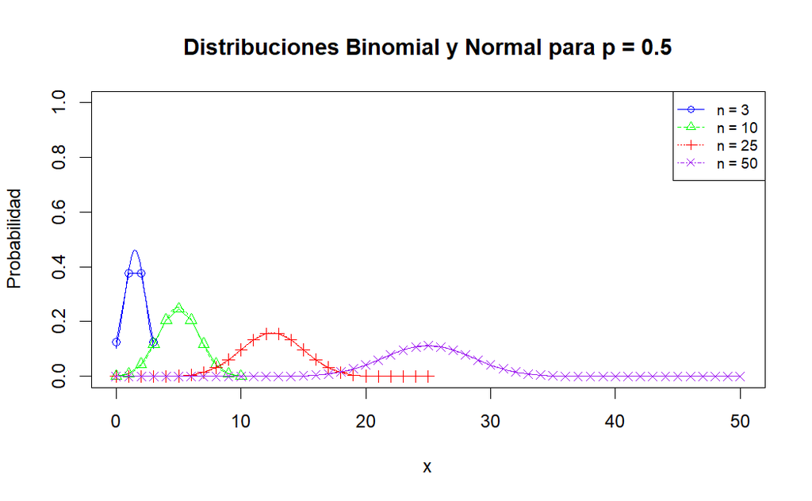

```r
# Crear gráficos para p = 0.5
plot_dbinomial_dnormal(0.5)
```

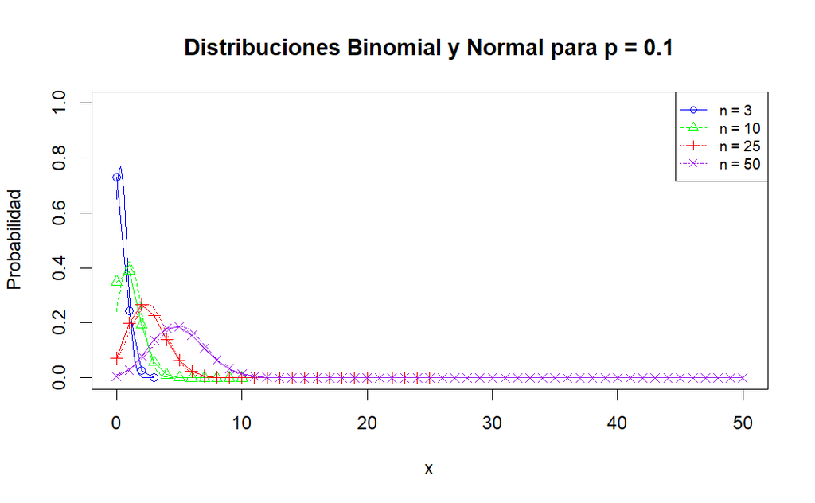

```r
# Crear gráficos para p = 0.1
plot_dbinomial_dnormal(0.1)
```

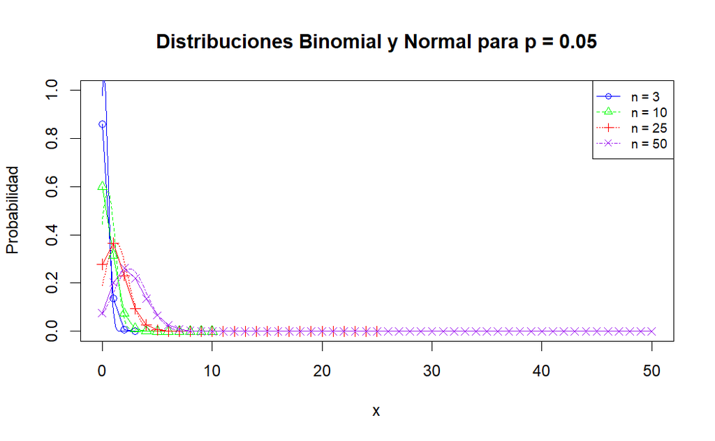

```r
# Crear gráficos para p = 0.05
plot_dbinomial_dnormal(0.05)
```

## Parte 2

Representar en un gráfico para cada valor de probabilidad p=0.5, 0.1 y 0.05, la evolución de la aproximación de las distribuciones binomiales con n=3,25,50 a su correspondiente distribución de Poisson (Nota: se debe hacer un gráfico para 0.5 con todas las n, otro para 0.1 con todas las n y otro para 0.05 con todas las n).

### Resolución

Debido a que debemos iterar para cada valor de probabilidad con su respectivo valor de n, crearemos una función que reciba como parámetro la probabilidad que se vaya a iterar sobre todos los valores de n desfinidos en el enunciado.Y realizaremos la sistematización del siguiente algoritmo:

1. Creamos la función que recibe como parámetro la probabilidad p.
2. establecemos los valores de estilo de nuestro gráfico, en este caso, los colores y el tipo de línea.
3. Definimos los valores de n que se van a iterar (3, 25, 50) en un vector.
4. Creamos un marco vacío para el gráfico y defino el inio del eje y en cero (0) para mejorar visiblidad.
5. Iteramos sobre los distintos valores de n.
   - Establecemos el rango de valores de x según el vector creado en el paso 3.
   - Calculamos la distribución binomial.
   - Calculamos la distribución de Poisson.
   - Agregamos las líneas al gráfico, utilizamos la variable “type” y “pch” para que se muestre el gráfico con puntos y líneas y un estilo diferente de punto por cada valor de “n”. Por último cerramos el ciclo.
6. Agregamos una leyenda al gráfico para mejorar la visualización.
7. Ejectuamos la función para cada valor de p.

```r
# Función para crear el gráfico para un valor de p dado
plot_approximation_poisson <- function(p) {
  # Establecer los colores para cada valor de n
  colors <- c("blue", "green", "red")

  # Establecer el rango de valores de n
  n_values <- c(3, 25, 50)

  # Crear un marco vacío para el gráfico y defino el inio del eje y en cero (0) para mejorar visiblidad
  plot(0, 0, xlim = c(0, max(n_values)), ylim = c(0, 1), xlab = "x", ylab = "Probabilidad",
       main = paste("Distribuciones Binomial y Poisson para p =", p), type = "n")

  # Iterar sobre los distintos valores de n
  for (i in 1:length(n_values)) {
    n <- n_values[i]

    # Rango de valores para x
    x_values <- 0:n

    # Calcular la distribución binomial
    binom_values <- dbinom(x_values, n, p)

    # Calcular la distribución de Poisson aproximada
    lambda <- n * p
    poisson_values <- dpois(x_values, lambda)

    # Agregar las líneas al gráfico
    lines(x_values, binom_values, col = colors[i], type = "o", pch = i)
    lines(x_values, poisson_values, col = colors[i], lty = i, lwd = 2)
  }

  # Añadir una leyenda
  legend("topright", legend = paste("n =", n_values), col = colors, lty = 1:length(n_values), pch = 1:length(n_values), cex = 0.8)
}
```

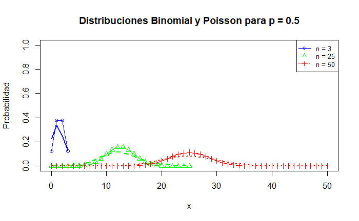

```r
# Crear gráficos para p = 0.5
plot_approximation_poisson(0.5)
```

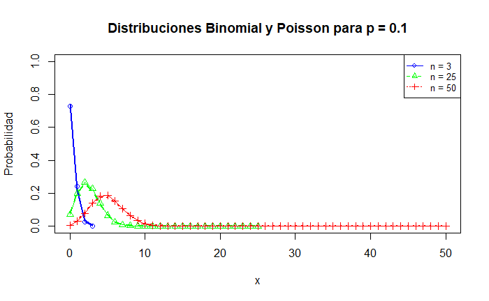

```r
# Crear gráficos para p = 0.1
plot_approximation_poisson(0.1)
```

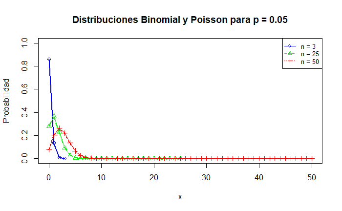

```r
# Crear gráficos para p = 0.05
plot_approximation_poisson(0.05)
```

## Parte 3

Analiza los 6 gráficos obtenidos y valora que aproximaciones son mejores indicando cuales han sido los factores determinantes.

# Tarea 2

## Parte 1

Indica cuál es el valor de $P(90\leq Xf \leq 100)$. Calcula todos los resultados aplicando las fórmulas sin usar R.

### Resolución

Se tiene que el peso promedio de mujeres es igual a 67.4 kg y la desviación típica de esta variable es 28.7.

Si se supone que la variable aleatoria continua sigue una distribución normal, es posible convertir esta distribución a una normal estándar N(0, 1). Se tiene entonces que al tipificar las variables:

- Para $Xf = 90$ kg, $Z = (90-67.4)/28.7 = 0.79$.
- Para $Xf = 100$ kg, $Z = (100-67.4)/28.7 = 1.14$.

De las tablas de probabilidad de una distribución normal estándar se tiene que:

$P(Z<=90) = 0.7852$ $P(Z<=100) = 0.8729$

Por tanto, $P(90 \leq Xf \leq 100) = 0.8729 - 0.7852 = 0.0877$.

## Parte 2

Calcula la probabilidad con R e inserta la representación en el mismo diagrama que la anterior. (Nota: este caso se trata de datos de mujeres).

### Resolución

Crearemos dos funciones, una para calcular la probabilidad de una distribución normal y otra para calcular la probabilidad de la variable aleatoria se encuentre en el rango definido. Para ellos realizaremos la sistematización del siguiente algoritmo:

1. Se define una función para calcular la probabilidad de una distribución normal.
   - Creamos un vector con los valores de la variable aleatoria.
   - Calculamos la función de densidad.
   - Graficamos la distribución normal.
   - Dibujamos el área bajo la curva de la distribución normal.
2. Se define una función para calcular la probabilidad de la variable aleatoria se encuentre en el rango definido.
3. Ejecutamos las funciones

```r
# Se define una función para mostrar la distribución normal
plot_normal_distribution <- function(initial_value, final_value, increment, mu, sd, x1, x2) {

  # Valores de la variable aleatoria
  var_values <- seq(initial_value, final_value, increment)

  # Función de densidad
  dens_function <- dnorm(var_values, mu, sd)

  # Gráfico de la distribución normal
  plot(var_values, dens_function, type="l", xlab="", ylab="", axes=FALSE)
  axis(side=1, at=c(initial_value, x1, x2, final_value), pos=0)

  # Se dibuja el área bajo la curva de la distribución normal
  dist_function_interval <- var_values >= x1 & var_values <= x2
  polygon(c(x1, var_values[dist_function_interval], x2), c(0, dens_function[dist_function_interval], 0), col="blue")

}
```

```r
# Se define una función para calcular la probabilidad de que la variable aleatoria peso se encuentre en un rango definido
normal_dist_prob <- function (mu, sd, x1, x2) {
  return (pnorm(x2, mu, sd) - pnorm(x1, mu, sd))
}
```

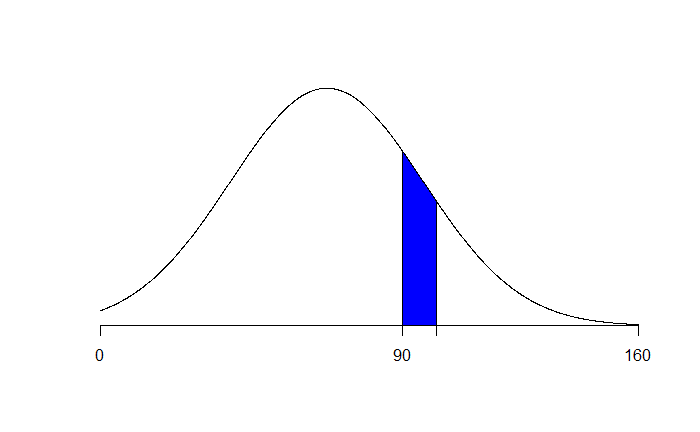

```r
# Se definen las variables de estudio
mean_weight = 67.4
standard_deviation = 28.7
value1 = 90
value2 = 100

# Se grafica la curva de distribución normal de la variable aleatoria peso de mujeres
plot_normal_distribution(0, 160, 0.1, mean_weight, standard_deviation, value1, value2)
```

```r
# Se ontiene la probabilidad
probability = normal_dist_prob(mean_weight, standard_deviation, value1, value2)
print(paste("La probabilidad de que el peso de una mujer se encuentre entre 90 y 100 kg es de", probability))
```

```
[1] "La probabilidad de que el peso de una mujer se encuentre entre 90 y 100 kg es de 0.0875057419158625"
```

# Tarea 3

## Enunciado

Se plantea el siguiente supuesto. Se sabe que 1 de cada 1000 personas sufren una pequeña reacción a una determinada vacuna. Cada cierto tiempo se realiza un muestreo de 2000 personas para determinar cómo evoluciona la reacción.

## Parte 1

Suponiendo que la muestra es una variable aleatoria $X_b$ que sigue una distribución binomial.

1. Calcula la probabilidad de la distribución
2. Representa gráficamente la distribución en R

### Resolución

Según el enunciado tenemos la siguiente información:

1. Tamaño de la muestra $X_b$: (rbinom)
2. probabilidad de que una persona sufra una reacción a la vacuna: $p = 1/1000 = 0.001$
3. número de personas que se muestrean: $n = 2000$

Con esta información, realizaríamos la sistematización del siguiente algoritmo:

1. Definimos los parámetros
2. Generamos una muestra aleatoria de la distribución binomial
3. Calculamos la probabilidad de la distribución binomial
4. Representamos gráficamente la distribución binomial

```r
# Parámetros
p <- 1/1000 # probabilidad de que una persona sufra una reacción a la vacuna
n <- 2000 # número de personas que se muestrean
size_muestra <- 30 # Tamaño de la muestra aleatoria

# Calculamos la probabilidad de la distribución binomial

Xb <- rbinom(n = size_muestra, size = n, prob = p) # Muestra aleatoria de la distribución binomial
prob <- dbinom(xb, n, p) # Probabilidad de la distribución binomial

print(xb)
```

[output not shown]

```r
print(prob)
```

```
 [1] 1.351999e-01 2.706705e-01 2.708060e-01 1.805373e-01 9.022348e-02 3.605327e-02 1.199971e-02
 [8] 3.421625e-03 8.532656e-04 1.890452e-04 3.767657e-05 6.822857e-06 1.132021e-06 1.732854e-07
[15] 2.461876e-08 3.262787e-09 4.051947e-10 4.733594e-11 5.220063e-12 5.450800e-13 5.404422e-14
[22] 5.100699e-15 4.592903e-16 3.953851e-17 3.260245e-18 2.579477e-19 1.961372e-20 1.435416e-21
[29] 1.012468e-22 6.891675e-24 4.532363e-25 2.883127e-26 1.775800e-27 1.060082e-28 6.139028e-30
[36] 3.451831e-31 1.886011e-32 1.002117e-33 5.181907e-35 2.609507e-36 1.280592e-37
```

Representamos gráficamente la distribución binomial.

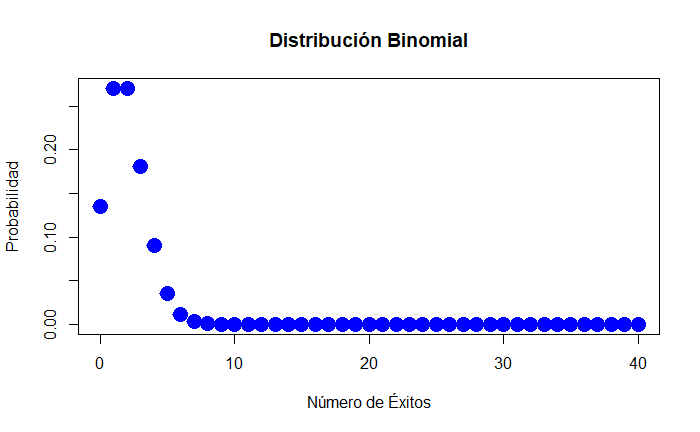

```r
# Gráfico de la distribución binomial
plot(xb, prob, col = "blue", lwd = 10, xlab = "Número de Éxitos", ylab = "Probabilidad", main = "Distribución Binomial")
```

## Parte 2

Compara la variable aleatoria anterior con la aproximación a una variable con distribución normal $X_n$.

1. Calcula la media y desviación típica de esta nueva variable
2. Inserta en la gráfica anterior la distribución normal obtenida.

### Resolución

Según el enunciado tenemos la siguiente información:

1. $\mu$ -> $n * p = 2000 * 0.001 = 2$
2. $\sigma$ -> $\sqrt{n * p * (1 - p)} = \sqrt{2000 * 0.001 * (1 - 0.001)} = 1.414$

Con esta información, realizaríamos la sistematización del siguiente algoritmo:

1. Definimos los parámetros
2. Generamos una muestra aleatoria de la distribución binomial
3. Calculamos la probabilidad de la distribución normal
4. Calculamos la media y desviación típica de la distribución normal
5. Representamos gráficamente la distribución binomial y la distribución normal

```r
# Parámetros de la distribución normal aproximada
mu <- n * p
sigma <- sqrt(n * p * (1 - p))

# Generar valores para la distribución normal
x_norm <- seq(min(Xb), max(Xb), length.out = 100)
y_norm <- dnorm(x_norm, mean = mu, sd = sigma) # Función de densidad de probabilidad de la distribución normal
```

```r
# Media y desviación típica de la distribución normal
media <- mean(x_norm)
desviacion_tipica <- sd(x_norm)

print(media)
```

```
[1] 3.5
```

```r
print(desviacion_tipica)
```

```
[1] 2.051318
```

Representamos gráficamente la distribución binomial y la distribución normal

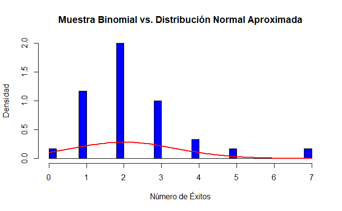

```r
# Graficar la muestra binomial y la distribución normal aproximada
hist(muestra_binomial, breaks = 40, probability = TRUE, col = "blue", xlab = "Número de Éxitos", ylab = "Densidad", main = "Muestra Binomial vs. Distribución Normal Aproximada")
lines(x_norm, y_norm, col = "red", lwd = 2)
```

## Parte 3

Compara la variable aleatoria anterior con la aproximación a una variable con distribución de Poisson $X_p$.

1. Calcula la tasa.
2. Inserta en la gráfica anterior la distribución de Poisson obtenida.

### Resolución

Según el enunciado tenemos la siguiente información:

1. $\lambda$ -> $n * p = 2000 * 0.001 = 2$
2. $X_p$ -> $X_p \sim Poisson(\lambda)$

Con esta información, realizaríamos la sistematización del siguiente algoritmo:

1. Definimos los parámetros
2. Calculamos la probabilidad de la distribución de Poisson
3. Calculamos la tasa de la distribución de Poisson
4. Representamos gráficamente la distribución binomial y la distribución de Poisson

```r
# Parámetros de la distribución de Poisson aproximada
lambda <- n * p
poisson_values <- dpois(xb, lambda)

tasa <- lambda / n

print(tasa)
```

```
[1] 0.001
```

Graficamos la distribución binomial y la distribución de Poisson

```r
# Graficar la muestra binomial, la distribución normal y la distribución de Poisson aproximada
plot(xb, prob, col = "blue", type = "o", lwd = 2, xlab = "Número de Éxitos", ylab = "Probabilidad", main = "Distribución Binomial vs D. Normal vs. D. de Poisson")
lines(x_norm, y_norm, col = "red", lwd = 2)
```

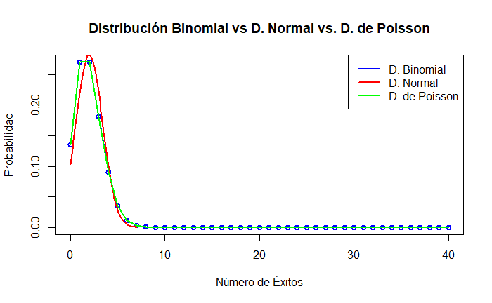

```r
lines(xb, poisson_values, col = "green", lwd = 2)

# Agregarmos una leyenda
legend("topright", c("D. Binomial", "D. Normal", "D. de Poisson"), col = c("blue", "red", "green"), lwd = c(1, 2, 2))
```

## Parte 4

Calcula los siguientes valores y compáralos con las aproximaciones a las distribuciones indicadas (realiza la corrección de continuidad que consideres necesaria).

- $P(X_b = 3)$
- $P(2 \leq X_b \leq 4)$
1. Calcular la aproximación según la distribución binomial.
2. Calcular la aproximación según la distribución normal.
3. Calcular la aproximación según la distribución de Poisson.

### Resolución

Según el enunciado tenemos la siguiente información:

1. $P(X_b = 3)$
2. $P(2 \leq X_b \leq 4)$

Con esta información, realizaríamos la sistematización del siguiente algoritmo:

1. Definimos los parámetros
2. Calculamos la probabilidad de la distribución binomial
3. Calculamos la probabilidad de la distribución normal
4. Calculamos la probabilidad de la distribución de Poisson
5. Representamos gráficamente los resultados obtenidos.

```r
# Parámetros
p <- 1/1000 # probabilidad de que una persona sufra una reacción a la vacuna
n <- 2000 # número de personas que se muestrean
mu <- n * p # media de la distribución binomial
sigma <- sqrt(n * p * (1 - p)) # desviación típica de la distribución binomial
lambda <- n * p # parámetro lambda de la distribución de Poisson

# Para P(Xb = 3)
# Calculamos la probabilidad de la distribución binomial
pb <- pbinom(3, n, p)
print(pb)
```

```
[1] 0.8572138
```

```r
# Calculamos la probabilidad de la distribución normal
pn <- pnorm(3, mean = mu, sd = sigma)
print(pn)
```

```
[1] 0.7603599
```

```r
# Calculamos la probabilidad de la distribución de Poisson
pp <- ppois(3, lambda = lambda)
print(pp)
```

```
[1] 0.8571235
```

Representamos gráficamente los resultados obtenidos (pb, pn, pp)

[figure not shown]

```r
# Creamos un gráfico de barras con pb, pn y pp
bp <- barplot(c(pb, pn, pp), names.arg = c("Binomial", "Normal", "Poisson"), col = c("blue", "red", "green"), main = "P(Xb = 3)", ylab = "Probabilidad", ylim = c(0, 1))
text(bp, c(pb, pn, pp), labels = c(pb, pn, pp), pos = 3, cex = 0.8)
```

$P(2 \leq X_b \leq 4)$

```r
# Para P(2 <= Xb <= 4)
# Calculamos la probabilidad de la distribución binomial
pb2 <- pbinom(4, n, p) - pbinom(1, n, p)
print(pb2)
```

```
[1] 0.5415668
```

```r
# Calculamos la probabilidad de la distribución normal
pn2 <- pnorm(4, mean = mu, sd = sigma) - pnorm(1, mean = mu, sd = sigma)
print(pn2)
```

```
[1] 0.6818141
```

```r
# Calculamos la probabilidad de la distribución de Poisson
pp2 <- ppois(4, lambda = lambda) - ppois(1, lambda = lambda)
print(pp2)
```

```
[1] 0.5413411
```

Representamos gráficamente los resultados obtenidos

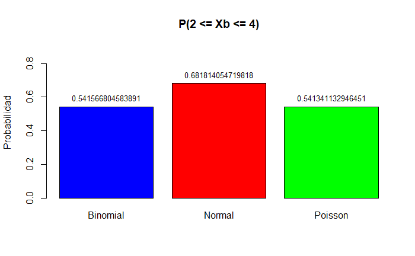

```r
# Graficar la muestra binomial, la distribución normal y la distribución de Poisson aproximada
bp <- barplot(c(pb2, pn2, pp2), names.arg = c("Binomial", "Normal", "Poisson"), col = c("blue", "red", "green"), main = "P(2 <= Xb <= 4)", ylab = "Probabilidad", ylim = c(0, 0.9))
text(bp, c(pb2, pn2, pp2), labels = c(pb2, pn2, pp2), pos = 3, cex = 0.8)
```

# Tarea 5

## Enunciado

Analiza las representaciones y los valores de probabilidad obtenidos e indica que aproximación es la más adecuada, justificando la respuesta e indicando los parámetros que han influido.

### Respuesta

Según los resultados obtenidos, la distribución de Poisson es la más adecuada para aproximar la distribución binomial, ya que los valores de probabilidad obtenidos son más cercanos a los valores de la distribución binomial.